# P9_02_etude_marche

[figure not shown]

**Objectif de l'entreprise**

La poule qui chante est une entreprise françcaise d'agroalimentaire. Elle souhaite se dévolopper à l'international. Le but est de déterminer les pays potentiels que l'on peut cibler pour l'exportation de poulets.

On cherche à cibler les pays avec les critères suivant :

- Une importation de viande de poulet élevée.
- Une population en croissance, la demande en poulet sera en agmentation.
- Un niveau correct d'alimentation, la disponiblité alimentaire doit être forte en kcal et protéines.
- Un bon niveau de consommation de protéines animales.
- Consommation de poulet avec un ratio élevé de protéines animales dans la consommation de leurs populations.
- Un PIB par habitant haut, la population a un bon pouvoir d'achat.
- Une stabilité politique élevée.

**Sommaire :**

- Mise en place de l'environnement
  - Importation des librairies
  - Constantes et configuration
  - Fonctions
  - Importation des données
  - Sélection variables quantitatives
- Initialisation
  - Aperçu du dataset
  - Centrage et réduction
- Classification Ascendante Hiérarchique
  - Méthode de clustering Ward
  - Dendrogramme
  - Clusters
- Méthode des K Means
  - Recherche du coude
  - Clusters
- Comparatif des méthodes
  - Visualisation des groupes par projection
  - Inertie inter et intra classes
  - Centroïdes
  - Méthodes préférentielle
- Analyse en Composantes Principales
  - Calcul des composantes principales
  - Eboulis des valeurs propres
  - Cercles de corrélations
  - Projection des individus
- Pays à cibler
- Conclusion

# Mise en place de l'environnement

## Importation des librairies

```python
import pandas as pd
import numpy as np
import os, sys

import matplotlib.pyplot as plt
import matplotlib.cm as cm
from matplotlib.collections import LineCollection
import seaborn as sns

from scipy.cluster.hierarchy import linkage, fcluster, dendrogram, centroid
from scipy.spatial.distance import pdist
from sklearn import decomposition, preprocessing
from sklearn.metrics import silhouette_score, silhouette_samples

import warnings
warnings.filterwarnings("ignore")
```

## Constantes et configuration

```python
# path to data folder
DATA_PATH = os.path.realpath('') + '/'

# Pandas settings
pd.set_option("display.max_columns", 50)
pd.set_option("display.max_rows", 100)
pd.options.display.float_format = '{:,.2f}'.format
```

## Fonctions

```python
def import_csv_to_dataframe(filename):
    try:
        return pd.read_csv(DATA_PATH + filename, encoding='utf8')
    except Exception as e:
        print(">>> Le fichier {} est introuvable.".format(filename))
        sys.exit(e)

def display_circles(pcs, n_comp, pca, axis_ranks, labels=None, label_rotation=0, lims=None):
    for d1, d2 in axis_ranks: # On affiche les 3 premiers plans factoriels, donc les 6 premières composantes
        if d2 < n_comp:

            # initialisation de la figure
            fig, ax = plt.subplots(figsize=(10,10))

            # détermination des limites du graphique
            if lims is not None :
                xmin, xmax, ymin, ymax = lims
            elif pcs.shape[1] < 30 :
                xmin, xmax, ymin, ymax = -1, 1, -1, 1
            else :
                xmin, xmax, ymin, ymax = min(pcs[d1,:]), max(pcs[d1,:]), min(pcs[d2,:]), max(pcs[d2,:])

            # affichage des flèches
            # s'il y a plus de 30 flèches, on n'affiche pas le triangle à leur extrémité
            if pcs.shape[1] < 30 :
                plt.quiver(np.zeros(pcs.shape[1]), np.zeros(pcs.shape[1]),
                   pcs[d1,:], pcs[d2,:],
                   angles='xy', scale_units='xy', scale=1, color="grey")
                # (voir la doc : https://matplotlib.org/api/_as_gen/matplotlib.pyplot.quiver.html)
            else:
                lines = [[[0,0],[x,y]] for x,y in pcs[[d1,d2]].T]
                ax.add_collection(LineCollection(lines, axes=ax, alpha=.1, color='black'))

            # affichage des noms des variables
            if labels is not None:
                for i,(x, y) in enumerate(pcs[[d1,d2]].T):
                    if x >= xmin and x <= xmax and y >= ymin and y <= ymax :
                        plt.text(x, y, labels[i], fontsize='14', ha='center', va='center', rotation=label_rotation, color="blue", alpha=0.5)

            # affichage du cercle
            circle = plt.Circle((0,0), 1, facecolor='none', edgecolor='b')
            plt.gca().add_artist(circle)

            # définition des limites du graphique
            plt.xlim(xmin, xmax)
            plt.ylim(ymin, ymax)

            # affichage des lignes horizontales et verticales
            plt.plot([-1, 1], [0, 0], color='grey', ls='--')
            plt.plot([0, 0], [-1, 1], color='grey', ls='--')

            # nom des axes, avec le pourcentage d'inertie expliqué
            plt.xlabel('F{} ({}%)'.format(d1+1, round(100*pca.explained_variance_ratio_[d1],1)))
            plt.ylabel('F{} ({}%)'.format(d2+1, round(100*pca.explained_variance_ratio_[d2],1)))

            plt.title("Cercle des corrélations (F{} et F{})".format(d1+1, d2+1))
            plt.show(block=False)

def display_factorial_planes(X_projected, n_comp, pca, axis_ranks, labels=None, alpha=1, illustrative_var=None):
    for d1,d2 in axis_ranks:
        if d2 < n_comp:

            # initialisation de la figure
            fig = plt.figure(figsize=(10,10))

            # affichage des points
            if illustrative_var is None:
                plt.scatter(X_projected[:, d1], X_projected[:, d2], alpha=alpha)
            else:
                illustrative_var = np.array(illustrative_var)
                for value in np.unique(illustrative_var):
                    selected = np.where(illustrative_var == value)
                    plt.scatter(X_projected[selected, d1], X_projected[selected, d2], alpha=alpha, label=value)
                plt.legend()

            # affichage des labels des points
            if labels is not None:
                for i,(x,y) in enumerate(X_projected[:,[d1,d2]]):
                    plt.text(x, y, labels[i],
                              fontsize='14', ha='center',va='center')

            # détermination des limites du graphique
            boundary = np.max(np.abs(X_projected[:, [d1,d2]])) * 1.1
            plt.xlim([-boundary,boundary])
            plt.ylim([-boundary,boundary])

            # affichage des lignes horizontales et verticales
            plt.plot([-100, 100], [0, 0], color='grey', ls='--')
            plt.plot([0, 0], [-100, 100], color='grey', ls='--')

            # nom des axes, avec le pourcentage d'inertie expliqué
            plt.xlabel('F{} ({}%)'.format(d1+1, round(100*pca.explained_variance_ratio_[d1],1)))
            plt.ylabel('F{} ({}%)'.format(d2+1, round(100*pca.explained_variance_ratio_[d2],1)))

            plt.title("Projection des individus (sur F{} et F{})".format(d1+1, d2+1))
            plt.show(block=False)

def display_scree_plot(pca):
    plt.figure(figsize=(10,10))
    scree = pca.explained_variance_ratio_*100
    plt.bar(np.arange(len(scree))+1, scree)
    plt.plot(np.arange(len(scree))+1, scree.cumsum(),c="red",marker='o')
    plt.xlabel("rang de l'axe d'inertie")
    plt.ylabel("pourcentage d'inertie")
    plt.title("Eboulis des valeurs propres")
    plt.show(block=False)

def plot_dendrogram(Z, names):
    plt.figure(figsize=(20,10))
    plt.title('Hierarchical Clustering Dendrogram')
    plt.xlabel('Area')
    plt.axhline(y=12, color='black', linestyle='dashed') # Threshold
    dendrogram(
        Z,
        labels = names,
        #orientation = "left",
    )
    plt.savefig('dendrogramme.png', format='png', bbox_inches='tight')
    plt.show()

    # Compute the silhouette scores for each sample
def silhouette_analysis(X, cluster_labels, n_clusters):

    plt.figure(figsize=(10,10))
    plt.xlim([-0.1, 1])
    plt.ylim([0, len(X) + (n_clusters + 1) * 10])

    sample_silhouette_values = silhouette_samples(X, cluster_labels)

    y_lower = 10
    for i in range(n_clusters):
        # Aggregate the silhouette scores for samples belonging to
        # cluster i, and sort them
        ith_cluster_silhouette_values = sample_silhouette_values[cluster_labels == i]

        ith_cluster_silhouette_values.sort()

        size_cluster_i = ith_cluster_silhouette_values.shape[0]
        y_upper = y_lower + size_cluster_i

        color = cm.nipy_spectral(float(i) / n_clusters)
        plt.fill_betweenx(np.arange(y_lower, y_upper),
                          0, ith_cluster_silhouette_values,
                          facecolor=color, edgecolor=color, alpha=0.7)

        # Label the silhouette plots with their cluster numbers at the middle
        plt.text(-0.05, y_lower + 0.5 * size_cluster_i, str(i))
        #ax1.text(-0.05, y_lower + 0.5 * size_cluster_i, str(i))

        # Compute the new y_lower for next plot
        y_lower = y_upper + 10  # 10 for the 0 samples

    plt.title("Analyse Silhouette des clusters")
    plt.xlabel("Coefficient silhouette")
    plt.ylabel("Cluster label")

    # The vertical line for average silhouette score of all the values
    plt.axvline(x=silhouette_avg, color="red", linestyle="--")

    plt.yticks([])  # Clear the yaxis labels / ticks
    plt.xticks([-0.1, 0, 0.2, 0.4, 0.6, 0.8, 1])
```

## Imporation des données

```python
data = import_csv_to_dataframe("data_prep.csv")
data.head(5)
```

|  | area | country_code | population | pop_evo | chicken_prod | chicken_import_quantity | food_supply_kcal | food_supply_protein | ratio_animal_protein | PIB | stability | dist_from_FRA |
| --- | --- | --- | --- | --- | --- | --- | --- | --- | --- | --- | --- | --- |
| 0 | Afghanistan | AFG | 37,171,921.00 | 15.19 | 0.78 | 0.67 | 744,600.00 | 20,264.80 | 70.94 | 2,033.80 | -2.75 | 5,594.22 |
| 1 | Albania | ALB | 2,882,740.00 | -0.72 | 5.55 | 4.16 | 1,226,400.00 | 42,245.10 | 194.74 | 13,323.80 | 0.38 | 1,603.94 |
| 2 | Algeria | DZA | 42,228,408.00 | 10.72 | 6.99 | 0.00 | 1,212,530.00 | 33,517.95 | 98.30 | 11,642.20 | -0.83 | 1,345.46 |
| 3 | American Samoa | ASM | 55,465.00 | -0.45 | NaN | NaN | NaN | NaN | NaN | NaN | 1.20 | 16,117.70 |
| 4 | Andorra | AND | 77,006.00 | -4.66 | NaN | NaN | NaN | NaN | NaN | NaN | 1.42 | 708.21 |

**Données pour l'année 2018 :**

- **population :** nombre d'habitants
- **pop_evo :** taux d'évolution de la population entre 2013 et 2018
- **chicken_prod :** production de viande de poulet en kg par habitant
- **chick_import_quantity :** importation de viande de poulet en kg par habitant
- **food_supply_kcal :** disponibilité en kcal par habitant.
- **food_supply_protein :** disponibilité en proteine par habitant.
- **ratio_animal_protein :** ratio de protéines animales dans la consommation.
- **PIB :** produit intérieur brut par habitant.
- **stability :** stabilité politique du pays.
- **dist_from_FRA :** distance de la france.

```python
data.info()
```

```
<class 'pandas.core.frame.DataFrame'>
RangeIndex: 236 entries, 0 to 235
Data columns (total 12 columns):
 #   Column                   Non-Null Count  Dtype
---  ------                   --------------  -----
 0   area                     236 non-null    object
 1   country_code             235 non-null    object
 2   population               236 non-null    float64
 3   pop_evo                  236 non-null    float64
 4   chicken_prod             171 non-null    float64
 5   chicken_import_quantity  173 non-null    float64
 6   food_supply_kcal         172 non-null    float64
 7   food_supply_protein      172 non-null    float64
 8   ratio_animal_protein     172 non-null    float64
 9   PIB                      186 non-null    float64
 10  stability                197 non-null    float64
 11  dist_from_FRA            212 non-null    float64
dtypes: float64(10), object(2)
memory usage: 22.2+ KB
```

Les données présentent des valeurs manquantes.

## Sélection variables quantitatives

On sélectionne uniquement les variables quantitatives pour faire une normalisation car les variables n'ont pas les mêmes unités. En même temps nous sélectionnons les pays qui ont toutes les variables renseignées.

```python
# Prepare data for normalization
data = data.replace([np.inf, -np.inf], np.nan).dropna().reset_index().drop(['index'], axis=1)
data.set_index('country_code', inplace=True)

# Select variables for analysis
df_main = data[[
    'chicken_prod',
    'chicken_import_quantity',
    'food_supply_kcal',
    'food_supply_protein',
    'ratio_animal_protein',
    'pop_evo',
    'PIB',
    'stability'
]]

df_main.head()
```

| country_code | chicken_prod | chicken_import_quantity | food_supply_kcal | food_supply_protein | ratio_animal_protein | pop_evo | PIB | stability |
| --- | --- | --- | --- | --- | --- | --- | --- | --- |
| AFG | 0.78 | 0.67 | 744,600.00 | 20,264.80 | 70.94 | 15.19 | 2,033.80 | -2.75 |
| ALB | 5.55 | 4.16 | 1,226,400.00 | 42,245.10 | 194.74 | -0.72 | 13,323.80 | 0.38 |
| DZA | 6.99 | 0.00 | 1,212,530.00 | 33,517.95 | 98.30 | 10.72 | 11,642.20 | -0.83 |
| AGO | 0.88 | 10.87 | 870,525.00 | 19,363.25 | 112.22 | 18.43 | 6,933.50 | -0.32 |
| ATG | 0.00 | 72.70 | 892,425.00 | 29,269.35 | 235.50 | 5.21 | 21,030.40 | 0.85 |

Vérification de la cohérence des données :

```python
df_main.describe()
```

|  | chicken_prod | chicken_import_quantity | food_supply_kcal | food_supply_protein | ratio_animal_protein | pop_evo | PIB | stability |
| --- | --- | --- | --- | --- | --- | --- | --- | --- |
| count | 157.00 | 157.00 | 157.00 | 157.00 | 157.00 | 157.00 | 157.00 | 157.00 |
| mean | 17.46 | 10.93 | 1,054,673.31 | 30,116.96 | 157.11 | 6.94 | 20,928.03 | -0.05 |
| std | 18.20 | 18.36 | 165,311.23 | 7,686.96 | 58.23 | 6.10 | 21,538.14 | 0.89 |
| min | 0.00 | 0.00 | 651,890.00 | 15,479.65 | 36.04 | -6.90 | 933.10 | -2.75 |
| 25% | 2.18 | 0.39 | 940,970.00 | 24,020.65 | 105.27 | 2.60 | 5,033.50 | -0.60 |
| 50% | 10.96 | 4.16 | 1,047,915.00 | 30,149.00 | 161.87 | 6.20 | 13,323.80 | 0.02 |
| 75% | 27.07 | 11.18 | 1,203,405.00 | 35,981.70 | 205.12 | 11.37 | 30,036.10 | 0.75 |
| max | 78.27 | 111.37 | 1,418,025.00 | 53,337.45 | 266.77 | 28.28 | 132,417.00 | 1.54 |

> L'analyse se ferra sur 157 pays.

# Initialisation

## Aperçu du dataset

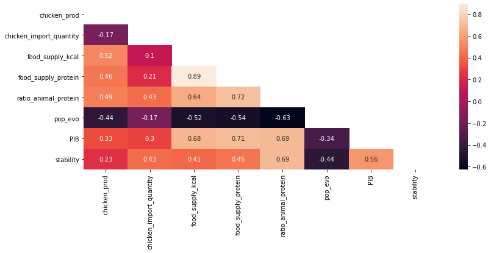

```python
matrix = df_main.corr()

mask = np.triu(np.ones_like(matrix, dtype=np.bool))
plt.figure(figsize=(13, 5))
sns.heatmap(matrix, mask=mask, annot=True)
plt.show()
```

On peut distinguer les possibles corrélations suivantes :

- Entre la disponibilité en protéines et la disponibilité en kcal.
- Entre le PIB et les différentes variables de la disponibilité alimentaire. Les pays les plus riches sont possiblement ceux qui consomment le plus.

## Centrage et réduction

Les variables sont exprimées dans des unités différentes. On applique un centrage et une réduction sur ces dernières afin que leurs moyennes respectives soient égales à 0 avec un écart-type de 1. Cela permettra aux variables d'influer de manière égale nos calcul.

```python
X = df_main.values
names = df_main.index

std_scale = preprocessing.StandardScaler().fit(X)
X_scaled = std_scale.transform(X)
df_norm = pd.DataFrame(X_scaled, columns=df_main.columns)
```

**Résultat du centrage et de la réduction :**

```python
df_norm.head()
```

|  | chicken_prod | chicken_import_quantity | food_supply_kcal | food_supply_protein | ratio_animal_protein | pop_evo | PIB | stability |
| --- | --- | --- | --- | --- | --- | --- | --- | --- |
| 0 | -0.92 | -0.56 | -1.88 | -1.29 | -1.48 | 1.36 | -0.88 | -3.04 |
| 1 | -0.66 | -0.37 | 1.04 | 1.58 | 0.65 | -1.26 | -0.35 | 0.48 |
| 2 | -0.58 | -0.60 | 0.96 | 0.44 | -1.01 | 0.62 | -0.43 | -0.88 |
| 3 | -0.91 | -0.00 | -1.12 | -1.40 | -0.77 | 1.89 | -0.65 | -0.30 |
| 4 | -0.96 | 3.37 | -0.98 | -0.11 | 1.35 | -0.28 | 0.00 | 1.01 |

```python
df_norm.to_csv('d_norm.csv', encoding='utf-8', index=False)
```

**Moyennes et variances :**

On vérifie que la moyenne de chaque variable est égale à 0 et que leurs variances soient égales à 1.

```python
df_norm.describe()
```

|  | chicken_prod | chicken_import_quantity | food_supply_kcal | food_supply_protein | ratio_animal_protein | pop_evo | PIB | stability |
| --- | --- | --- | --- | --- | --- | --- | --- | --- |
| count | 157.00 | 157.00 | 157.00 | 157.00 | 157.00 | 157.00 | 157.00 | 157.00 |
| mean | -0.00 | -0.00 | 0.00 | -0.00 | -0.00 | 0.00 | 0.00 | 0.00 |
| std | 1.00 | 1.00 | 1.00 | 1.00 | 1.00 | 1.00 | 1.00 | 1.00 |
| min | -0.96 | -0.60 | -2.44 | -1.91 | -2.09 | -2.28 | -0.93 | -3.04 |
| 25% | -0.84 | -0.58 | -0.69 | -0.80 | -0.89 | -0.71 | -0.74 | -0.62 |
| 50% | -0.36 | -0.37 | -0.04 | 0.00 | 0.08 | -0.12 | -0.35 | 0.08 |
| 75% | 0.53 | 0.01 | 0.90 | 0.77 | 0.83 | 0.73 | 0.42 | 0.90 |
| max | 3.35 | 5.49 | 2.21 | 3.03 | 1.89 | 3.51 | 5.19 | 1.79 |

> Les données sont bien normalisés, on peut donc faire en premier lieu une classification ascendante hiérarchique.

# Classification Ascendante Hiérarchique

## Méthode de clustering Ward

Nous allons pouvoir mettre en évidence des liens hiérarchiques entre individus et détecter le nombre de classes "naturelles" au sein des pays. La Classification Ascendante Hiérarchique (CAH) permet de faire cette première approche en utilisans les distances euclidiennes. Le dendogramme présente des groupes et permet de déduire un nombre de classes.

La méthode de Ward :

- Au départ 1 classe : 1 individu => inertie inter classe = 1
- A chaque étape : agregation pour minimiser la diminution de l'inter classe.

## Dendrogramme

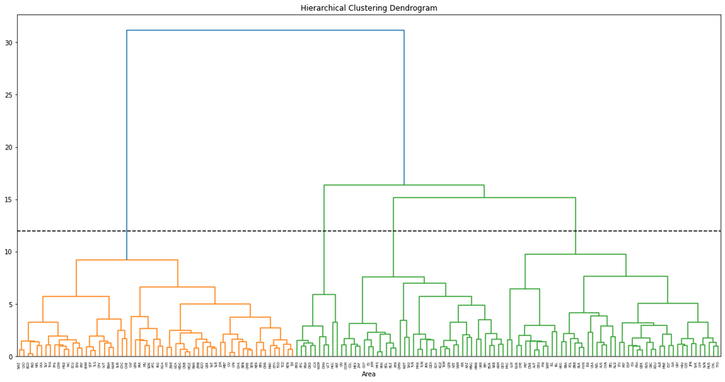

```python
Z = linkage(X_scaled, 'ward', metric='euclidean')
plot_dendrogram(Z, names)
```

> Le dendrogramme "suggère" un découpage en 4 groupes. Ce choix correspond aux plus grands sauts entre deux clusters consécutifs là où il y a la plus grande réduction d'inertie intra-classes.

## Clusters CAH

Nous allons calculer le nombre pays par groupe et déterminer leurs caractéristiques.

```python
# Find clusters
cah_n_clusters = 4
cah_clusters = fcluster(Z, cah_n_clusters, criterion='maxclust')

# Begin clusters list from 0
cah_clusters = [x-1 for x in cah_clusters]

# Add cluster number to each area
df_cah = df_main.copy()
df_cah['clusters'] = cah_clusters

df_norm['cah_clusters'] = cah_clusters
```

**Répartition des effectifs :**

```python
df_cah_clusters = df_main.groupby(cah_clusters)
df_cah_clusters.size()
```

```
0    62
1    10
2    37
3    48
dtype: int64
```

La répartition des pays est hétérogène.

**Moyennes par groupe :**

```python
df_cah_clusters.mean()
```

|  | chicken_prod | chicken_import_quantity | food_supply_kcal | food_supply_protein | ratio_animal_protein | pop_evo | PIB | stability |
| --- | --- | --- | --- | --- | --- | --- | --- | --- |
| 0 | 5.39 | 4.69 | 904,552.42 | 22,770.47 | 101.40 | 11.54 | 5,667.38 | -0.63 |
| 1 | 4.65 | 70.99 | 1,030,504.50 | 32,520.41 | 219.86 | 3.38 | 27,437.21 | 0.91 |
| 2 | 23.01 | 6.34 | 1,097,870.68 | 31,571.71 | 159.03 | 6.59 | 16,338.50 | -0.25 |
| 3 | 31.44 | 10.03 | 1,220,316.67 | 37,984.11 | 214.50 | 2.02 | 42,821.40 | 0.65 |

Le clustering de la méthode permet déja de distinguer les groupes par leurs caractéristiques.

# Méthode des KMeans

Avec la méthode des K-Means, nous cherchons la position des centres qui minimisent la distance entre les points d'un cluster et le centre de ce dernier.

## Recherche du coude

Nous allons rechercher le nombre de cluster qui réprésente au mieux nos pays en traçant la courbe de l’inertie. Pour cela, on identifiera avec la méthode du coude une rupture significative de la décroissance de la courbe du coût du model.

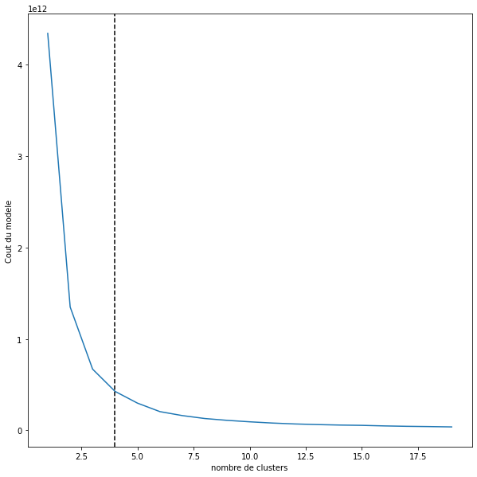

```python
from sklearn import cluster

inertia = []
K_range = range(1, 20)
for k in K_range:
    model = cluster.KMeans(n_clusters=k).fit(X)
    inertia.append(model.inertia_)

plt.figure(figsize=(10,10))
plt.plot(K_range, inertia)
plt.axvline(x=4, color='black', linestyle='dashed')
plt.xlabel('nombre de clusters')
plt.ylabel('Cout du modele')
```

La zone la plus marquée par le coude se situe entre k=3 et k=5. Nous choisisons pour la suite de l'analyse k=4.

## Clusters KMeans

**Calculs :**

```python
# Nombre de clusters souhaités
n_clust = 4

# Clustering par K-means
model = cluster.KMeans(n_clusters=n_clust)
model.fit(X_scaled)

# Récupération des clusters attribués à chaque individu
k_means_clusters = model.labels_
df_norm['k_means_clusters'] = model.labels_

# Copie dataframe
df_km = df_main.copy()
df_km['clusters'] = model.labels_
```

Gràce aux calculs, nous pouvons récupérer les numéros de clusters de chacun des pays (model.labels_).

**Répartions des effectifs :**

```python
df_km_group = df_km.groupby(model.labels_)
df_km_group.size()
```

```
0    10
1    39
2    59
3    49
dtype: int64
```

On retrouve comme pour la CAH des groupes hétérogènes.

**Moyennes par classes :**

```python
df_km_group.mean()
```

|  | chicken_prod | chicken_import_quantity | food_supply_kcal | food_supply_protein | ratio_animal_protein | pop_evo | PIB | stability | clusters |
| --- | --- | --- | --- | --- | --- | --- | --- | --- | --- |
| 0 | 4.65 | 70.99 | 1,030,504.50 | 32,520.41 | 219.86 | 3.38 | 27,437.21 | 0.91 | 0 |
| 1 | 29.39 | 11.53 | 1,243,957.44 | 39,361.69 | 218.67 | 2.35 | 47,764.26 | 0.69 | 1 |
| 2 | 4.06 | 4.72 | 901,655.17 | 22,896.94 | 99.39 | 12.35 | 5,334.86 | -0.64 | 2 |
| 3 | 26.71 | 5.68 | 1,093,197.35 | 30,961.91 | 164.80 | 4.82 | 17,015.63 | -0.13 | 3 |

Le clustering de la méthode K-Means permet là aussi de distinguer les groupes par leurs caractéristiques.

# Comparatif des méthodes

La CAH et la méthode des K-Means nous ont parmis chacun de répartir les pays en 4 groupes. Nous allons comparer les deux méthodes pour en sélectionner une.

## Visualisation des groupes par projection

```python
pca = decomposition.PCA(n_components=2).fit(X_scaled)
X_projected = pca.transform(X_scaled)
```

**Classification Ascendante Hiérarchique :**

Calcul centroïdes :

```python
df_Z_CAH = pd.DataFrame(X_scaled)
df_Z_CAH['clusters'] = cah_clusters
df_Z_CAH_mean = df_Z_CAH.groupby('clusters').mean()
X_CAH = df_Z_CAH_mean.values
X_CAH_projected = pca.transform(X_CAH)
```

Visualisation :

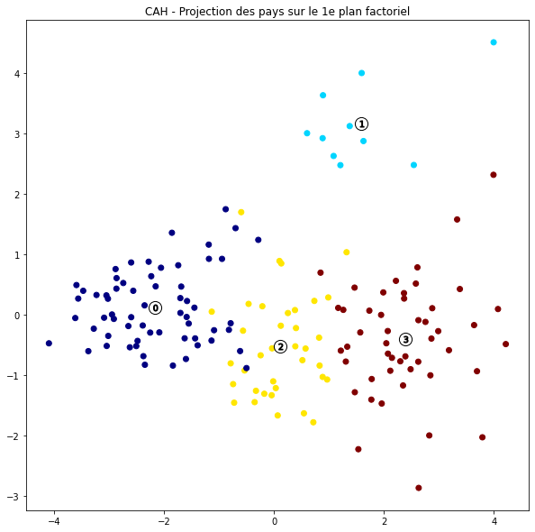

```python
plt.figure(figsize=(10,10))
plt.scatter(X_projected[:, 0], X_projected[:, 1], c=cah_clusters, cmap = 'jet')

plt.scatter(X_CAH_projected[:, 0], X_CAH_projected[:, 1], marker='o',
                c="white", alpha=1, s=200, edgecolor='k')
for i, c in enumerate(X_CAH_projected):
        plt.scatter(c[0], c[1], marker='$%d$' % i, alpha=1,
                    s=50, edgecolor='k')

plt.title("CAH - Projection des pays sur le 1e plan factoriel")
plt.show(block=False)
```

**K-means :**

```python
centroids = model.cluster_centers_
centroids_projected = pca.transform(centroids)

X_projected = pca.transform(X_scaled)
```

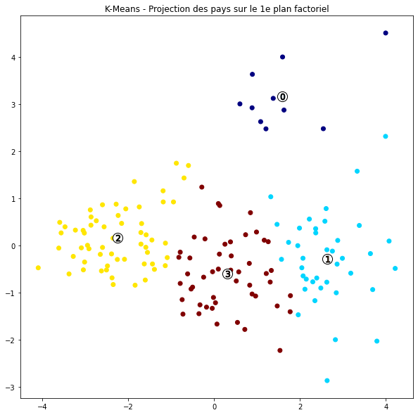

```python
plt.figure(figsize=(10,10))
plt.scatter(X_projected[:, 0], X_projected[:, 1], c=k_means_clusters.astype(np.float),
            cmap = 'jet')
plt.scatter(centroids_projected[:, 0], centroids_projected[:, 1], marker='o',
                c="white", alpha=1, s=200, edgecolor='k')
for i, c in enumerate(centroids_projected):
        plt.scatter(c[0], c[1], marker='$%d$' % i, alpha=1,
                    s=80, edgecolor='k')

plt.title("K-Means - Projection des pays sur le 1e plan factoriel")
plt.show(block=False)
```

## Inertie inter et intra classes

Nous allons comparer les deux méthodes en analysant leurs inerties intra et inter-classes. Nous cherchons à avoir :

- la variation intra-classe la plus petite
- la variation inter-classe la plus grande

Pour cela, on va utiliser le score Silhouette de SkLearn pour évaluer la qualité des clusters.  
Ce score varie de -1 à 1. Si le score est de 1, le cluster est dense et bien séparé par rapport aux autres clusters. Une proche de 0 représente des clusters qui se chevauchent avec des échantillons très proches de la frontière de valeur des clusters voisins.

```
The average CAH silhouette_score is : 0.2629630345373933
```

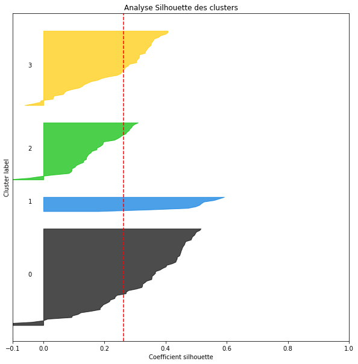

```python
silhouette_avg = silhouette_score(X_scaled, cah_clusters)
print("The average CAH silhouette_score is :", silhouette_avg)

cah_clusters_array = np.array(cah_clusters)
silhouette_analysis(X_scaled, cah_clusters_array, n_clust)
```

```
The average K-Means silhouette_score is : 0.2819083543906498
```

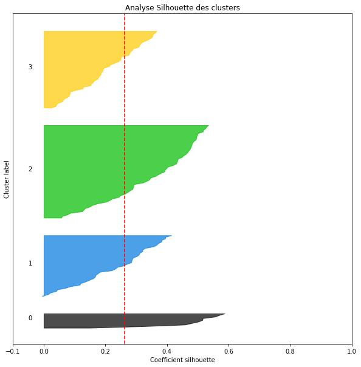

```python
silhouette_analysis(X_scaled, k_means_clusters, n_clust)
silhouette_avg = silhouette_score(X_scaled, k_means_clusters)
print("The average K-Means silhouette_score is :", silhouette_avg)
```

> Les score silhouette et donc l'inertie inter-classes des 2 méthodes sont proches. La méthode des K-Means présente des groupes plus définies que celle de la CAH. Elle présente moins de outliers.

## Méthode préférentielle

> Au vue des résultats, nous allons utiliser préférentiellement la méthodes des K-Means pour notre classification et la suite de l'analyse.

```python
df_norm = df_norm.drop("cah_clusters", axis=1)
```

**Liste des pays par groupes :**

```python
clusters_list_nb = list(df_km['clusters'].unique())
clusters_list_nb.sort()

for clut in clusters_list_nb :
    df_temp = df_km.loc[df_km['clusters'] == clut]
    print(clut)
    print(df_temp.index.values)
```

```
0
['ATG' 'BHS' 'HKG' 'DMA' 'GRD' 'KNA' 'LCA' 'VCT' 'WSM' 'ARE']
1
['ALB' 'ARG' 'AUS' 'AUT' 'BEL' 'CAN' 'MAC' 'HRV' 'CZE' 'DNK' 'EST' 'FIN'
 'FRA' 'DEU' 'GRC' 'HUN' 'ISL' 'IRL' 'ISR' 'ITA' 'JPN' 'KWT' 'LVA' 'LTU'
 'LUX' 'MLT' 'MNE' 'NLD' 'NZL' 'NOR' 'POL' 'PRT' 'ROU' 'SVN' 'ESP' 'SWE'
 'CHE' 'GBR' 'USA']
2
['AFG' 'AGO' 'BGD' 'BEN' 'BWA' 'BFA' 'CPV' 'KHM' 'CMR' 'CAF' 'TCD' 'COG'
 'CIV' 'SWZ' 'ETH' 'GAB' 'GMB' 'GHA' 'GTM' 'GIN' 'GNB' 'HTI' 'HND' 'IND'
 'IDN' 'IRQ' 'JOR' 'KEN' 'KGZ' 'LBN' 'LSO' 'LBR' 'MDG' 'MWI' 'MLI' 'MRT'
 'MOZ' 'NAM' 'NPL' 'NIC' 'NER' 'NGA' 'OMN' 'PAK' 'PHL' 'RWA' 'STP' 'SEN'
 'SLE' 'SLB' 'LKA' 'SDN' 'TJK' 'TLS' 'TGO' 'UGA' 'VUT' 'ZMB' 'ZWE']
3
['DZA' 'ARM' 'AZE' 'BRB' 'BLR' 'BLZ' 'BOL' 'BIH' 'BRA' 'BGR' 'CHL' 'COL'
 'CRI' 'CYP' 'DOM' 'ECU' 'EGY' 'SLV' 'FJI' 'GEO' 'GUY' 'IRN' 'JAM' 'KAZ'
 'KIR' 'MYS' 'MUS' 'MEX' 'MNG' 'MAR' 'MMR' 'PAN' 'PRY' 'PER' 'RUS' 'SAU'
 'SRB' 'SVK' 'ZAF' 'SUR' 'THA' 'TTO' 'TUN' 'TUR' 'TKM' 'UKR' 'URY' 'UZB'
 'VNM']
```

**Moyenne par groupes :**

```python
df_km_group = df_km.groupby(model.labels_).mean()
df_km_group
```

|  | chicken_prod | chicken_import_quantity | food_supply_kcal | food_supply_protein | ratio_animal_protein | pop_evo | PIB | stability | clusters |
| --- | --- | --- | --- | --- | --- | --- | --- | --- | --- |
| 0 | 4.65 | 70.99 | 1,030,504.50 | 32,520.41 | 219.86 | 3.38 | 27,437.21 | 0.91 | 0 |
| 1 | 29.39 | 11.53 | 1,243,957.44 | 39,361.69 | 218.67 | 2.35 | 47,764.26 | 0.69 | 1 |
| 2 | 4.06 | 4.72 | 901,655.17 | 22,896.94 | 99.39 | 12.35 | 5,334.86 | -0.64 | 2 |
| 3 | 26.71 | 5.68 | 1,093,197.35 | 30,961.91 | 164.80 | 4.82 | 17,015.63 | -0.13 | 3 |

**Heatmap :**

```python
df = pd.DataFrame(centroids, columns = df_main.columns,
                      index = df_km_group.index)
df = df.T
```

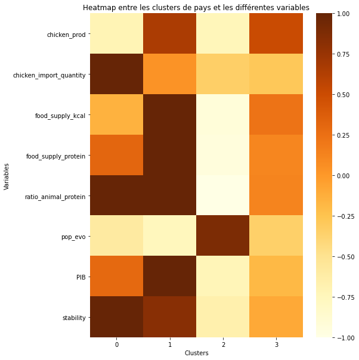

```python
plt.figure(figsize=(8,10))
heatmap_fig = sns.heatmap(df, vmin=-1, vmax=1, cmap="YlOrBr")
plt.title("Heatmap entre les clusters de pays et les différentes variables")
plt.xlabel("Clusters")
plt.ylabel("Variables")
plt.show()
fig = heatmap_fig.get_figure()
fig.savefig('pqc_heatmap.jpg', bbox_inches='tight')
```

On retrouve pour chacune des différentes classes des points communs entre pays.

**Groupe 2 :** Les pays ne produisent pas et n'importe pas beaucoup de poulet. Ils présentent un ratio de proteines dans la consommation le plus faible. Le PIB est bas. Ils ne seraient pas de bons candidats pour notre exportation.

**Groupe 3 :** Les pays de se groupe sont producteurs de poulet. La quantité importée est faible et le PIB est moyen.

> Nous nous orientons à première vue vers les pays du **groupe 0 et 1**, qui présentent une forte demande en poulet et qui possèdent un PIB élevé. Les exportations se feront en plus grande quantité avec un prix d'achat plus élevé. Les pays des groupe 2 et 3 ne semblent pas avec assez d'indicateurs au verts.

# Analyse en Composantes Principales

On étudie ici :

- La variabilité entre les individus.
- Les liaisons entre les variables.

## Calcul des composantes principales

```python
# choix du nombre de composantes à calculer
n_comp = 4

#Sélection des colonnes à prendre en compte dans l'ACP
data_pca = df_norm[[
    'pop_evo',
    'food_supply_protein',
    'ratio_animal_protein',
    'food_supply_kcal',
    'chicken_import_quantity',
    'chicken_prod',
    'PIB',
    'stability'
]]

# préparation des données pour l'ACP
X = data_pca.values
features = data_pca.columns

# Centrage et Réduction
std_scale = preprocessing.StandardScaler().fit(X)
X_scaled = std_scale.transform(X)

# Calcul des composantes principales
pca = decomposition.PCA(n_components=n_comp)
pca.fit(X_scaled)
```

```
PCA(n_components=4)
```

## Eboulis des valeurs propres

Afin de déterminer le nombre de composantes à analyser, on analyse le pourcentage d'inertie par rapport au nombres de composantes.

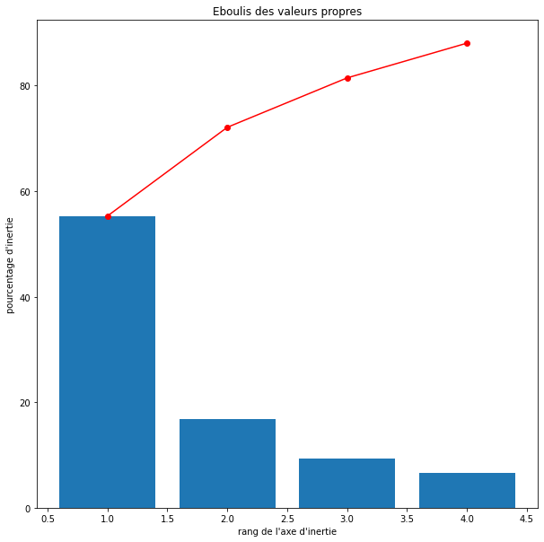

```python
display_scree_plot(pca)
```

> Le choix de 4 composantes est bon car celle-ci représentent une bonne partie de l'informations.

## Cercles de corrélations

Les cercles de corrélations vont nous permettre d'analyser les axes principaux d'inertie du nuage des variables.

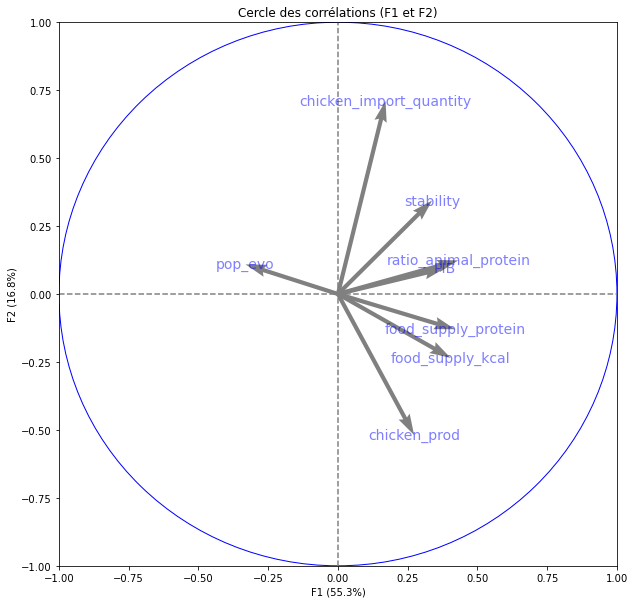

```python
pcs = pca.components_
display_circles(pcs, n_comp, pca, [(0,1)], labels = np.array(features))
```

**Composante F1 :**  
La composante F1 représente 55% de l'inertie totale. Elle représente l'indice du besoin alimentaire des pays par les variables :

- food_supply_kcal : disponibilité en kcal par habitant.
- food_supply_protein : disponibilité en proteine par habitant.
- ratio_animal_protein : ratio de protéines animales dans la consommation.

Plus l'indice est élevé, plus le pays consommera de la nourriture.

**Composante F2 :**  
La composante F2 représente 17% de l'inertie totale. Elle représente le manque de viande de poulet des pays.

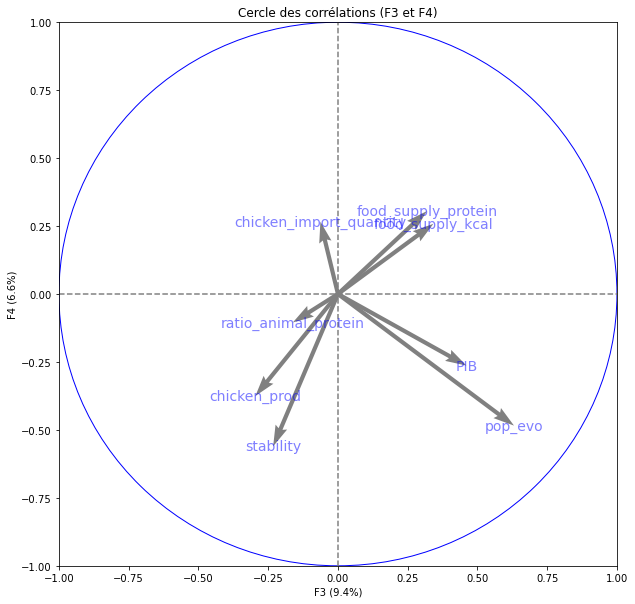

```python
display_circles(pcs, n_comp, pca, [(2,3)], labels = np.array(features))
```

**Composante F3 :**  
La composante F3 représente 9% de l'inertie totale. Elle représente l'indice économique des pays par les variables :

- pop_evo : taux d'évolution de la population entre 2013 et 2018
- PIB :

Plus l'indice est élevé, plus le pays est en developpement.

**Composante F4 :**  
La composante F4 représente environ 7% de l'inertie totale. Elle représente la stabilité des pays.

> Ces composantes vont nous permettre de caractériser les pays suivants les critères les plus propices à notre importation.

## Projection des individus

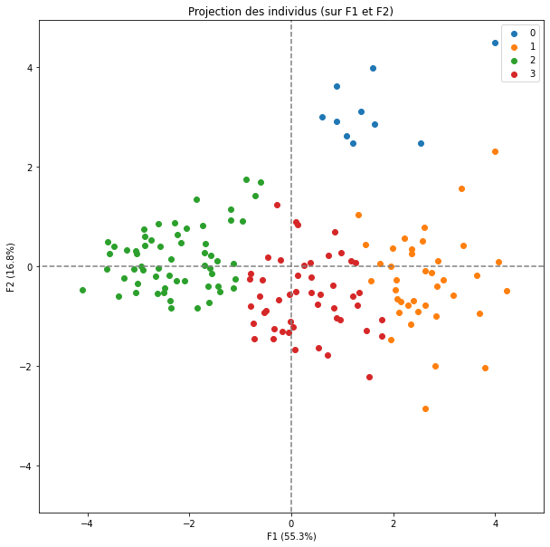

```python
# Projection des individus
X_projected = pca.transform(X_scaled)
display_factorial_planes(X_projected, n_comp, pca, [(0,1)], illustrative_var = df_norm["k_means_clusters"])
plt.show()
```

> Les pays à cibler sur la premier plan sont donc les pays en haut à droite de la représentation.

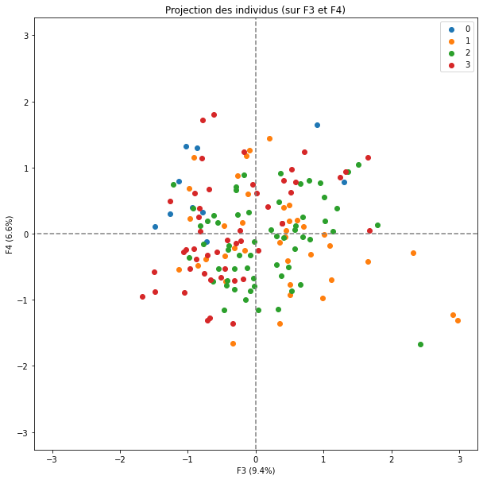

```python
# Projection des individus
display_factorial_planes(X_projected, n_comp, pca, [(2,3)], illustrative_var = df_norm["k_means_clusters"])
plt.show()
```

# Pays à cibler

Pour cibler les pays candidats à notre importation de poulet, nous allons calculer un score pondéré en fonction des 4 composantes vu plus haut.

```python
df_comp = pd.DataFrame(pca.fit_transform(X_scaled), index=df_main.index)
df_comp.columns = ['F1', 'F2', 'F3', 'F4']
df_comp['f_score'] = df_comp['F1'] * 0.55 + df_comp['F2']*0.17 + df_comp['F3']*0.09 + df_comp['F4']*-0.07
df_comp.head(4)
```

| country_code | F1 | F2 | F3 | F4 | f_score |
| --- | --- | --- | --- | --- | --- |
| AFG | -4.10 | -0.48 | 0.65 | 0.75 | -2.33 |
| ALB | 1.57 | -0.30 | -0.10 | 1.26 | 0.71 |
| DZA | -0.79 | -0.81 | 1.24 | 0.85 | -0.52 |
| AGO | -2.60 | 0.86 | 0.53 | -0.86 | -1.18 |

On crée un dataframe avec les indicateurs par pays :

```python
pays_cibles = data.copy()
pays_cibles["clusters"] = model.labels_
pays_cibles["F1"] = df_comp["F1"]
pays_cibles["F2"] = df_comp["F2"]
pays_cibles["F3"] = df_comp["F3"]
pays_cibles["F4"] = df_comp["F4"]
pays_cibles["f_score"] = df_comp["f_score"]
```

**Top 10 des pays cibles :**

```python
pays_cibles = pays_cibles[pays_cibles["f_score"]>0]
best_country = pays_cibles.sort_values('f_score', ascending=False).head(10)
best_country
```

| country_code | area | population | pop_evo | chicken_prod | chicken_import_quantity | food_supply_kcal | food_supply_protein | ratio_animal_protein | PIB | stability | dist_from_FRA | clusters | F1 | F2 | F3 | F4 | f_score |
| --- | --- | --- | --- | --- | --- | --- | --- | --- | --- | --- | --- | --- | --- | --- | --- | --- | --- |
| MAC | China, Macao SAR | 631,636.00 | 9.40 | 6.33 | 41.16 | 1,214,355.00 | 39,956.55 | 236.43 | 132,417.00 | 1.26 | 9,614.59 | 1 | 3.99 | 2.31 | 2.90 | -1.22 | 2.94 |
| HKG | China, Hong Kong SAR | 7,371,730.00 | 3.99 | 3.39 | 111.37 | 1,192,455.00 | 46,913.45 | 266.77 | 61,062.90 | 0.79 | 9,645.86 | 0 | 4.00 | 4.50 | 0.90 | 1.65 | 2.93 |
| LUX | Luxembourg | 604,245.00 | 11.37 | 0.00 | 19.86 | 1,264,725.00 | 39,657.25 | 226.66 | 113,590.00 | 1.37 | 287.97 | 1 | 3.33 | 1.57 | 2.97 | -1.31 | 2.46 |
| IRL | Ireland | 4,818,690.00 | 4.40 | 31.13 | 21.79 | 1,418,025.00 | 42,916.70 | 223.54 | 84,303.30 | 1.03 | 780.84 | 1 | 4.07 | 0.09 | 1.65 | -0.42 | 2.43 |
| ISL | Iceland | 336,713.00 | 2.91 | 26.73 | 2.97 | 1,333,710.00 | 53,337.45 | 262.22 | 56,722.10 | 1.41 | 2,235.75 | 1 | 4.22 | -0.49 | 1.09 | -0.18 | 2.35 |
| NLD | Netherlands | 17,059,560.00 | 1.28 | 62.96 | 34.29 | 1,203,405.00 | 38,941.85 | 238.83 | 56,060.90 | 0.86 | 430.89 | 1 | 3.64 | -0.18 | -0.45 | -0.72 | 1.98 |
| DNK | Denmark | 5,752,126.00 | 2.02 | 27.12 | 24.51 | 1,241,365.00 | 42,734.20 | 248.56 | 56,281.30 | 0.95 | 1,028.88 | 1 | 3.38 | 0.42 | 0.44 | -0.05 | 1.97 |
| ARE | United Arab Emirates | 9,630,959.00 | 4.71 | 4.98 | 63.23 | 1,209,610.00 | 40,244.90 | 167.04 | 66,968.20 | 0.71 | 5,251.80 | 0 | 2.54 | 2.47 | 1.30 | 0.78 | 1.88 |
| USA | United States of America | 327,096,265.00 | 3.38 | 68.17 | 0.39 | 1,380,430.00 | 41,515.10 | 235.80 | 61,585.80 | 0.47 | 5,852.74 | 1 | 3.79 | -2.03 | 0.51 | -0.92 | 1.85 |
| LTU | Lithuania | 2,801,264.00 | -6.90 | 47.84 | 16.06 | 1,245,015.00 | 46,227.25 | 227.24 | 35,427.50 | 0.75 | 1,701.10 | 1 | 3.69 | -0.94 | -0.98 | 0.68 | 1.74 |

Les pays font parties des groupes 0 et 1 que nous avions pré-sélectionné plus haut.

Pour affiner notre sélection, nous pouvons classer ces pays en ordre croissant de distance avec la France.

```python
best_country.sort_values('dist_from_FRA')
```

| country_code | area | population | pop_evo | chicken_prod | chicken_import_quantity | food_supply_kcal | food_supply_protein | ratio_animal_protein | PIB | stability | dist_from_FRA | clusters | F1 | F2 | F3 | F4 | f_score |
| --- | --- | --- | --- | --- | --- | --- | --- | --- | --- | --- | --- | --- | --- | --- | --- | --- | --- |
| LUX | Luxembourg | 604,245.00 | 11.37 | 0.00 | 19.86 | 1,264,725.00 | 39,657.25 | 226.66 | 113,590.00 | 1.37 | 287.97 | 1 | 3.33 | 1.57 | 2.97 | -1.31 | 2.46 |
| NLD | Netherlands | 17,059,560.00 | 1.28 | 62.96 | 34.29 | 1,203,405.00 | 38,941.85 | 238.83 | 56,060.90 | 0.86 | 430.89 | 1 | 3.64 | -0.18 | -0.45 | -0.72 | 1.98 |
| IRL | Ireland | 4,818,690.00 | 4.40 | 31.13 | 21.79 | 1,418,025.00 | 42,916.70 | 223.54 | 84,303.30 | 1.03 | 780.84 | 1 | 4.07 | 0.09 | 1.65 | -0.42 | 2.43 |
| DNK | Denmark | 5,752,126.00 | 2.02 | 27.12 | 24.51 | 1,241,365.00 | 42,734.20 | 248.56 | 56,281.30 | 0.95 | 1,028.88 | 1 | 3.38 | 0.42 | 0.44 | -0.05 | 1.97 |
| LTU | Lithuania | 2,801,264.00 | -6.90 | 47.84 | 16.06 | 1,245,015.00 | 46,227.25 | 227.24 | 35,427.50 | 0.75 | 1,701.10 | 1 | 3.69 | -0.94 | -0.98 | 0.68 | 1.74 |
| ISL | Iceland | 336,713.00 | 2.91 | 26.73 | 2.97 | 1,333,710.00 | 53,337.45 | 262.22 | 56,722.10 | 1.41 | 2,235.75 | 1 | 4.22 | -0.49 | 1.09 | -0.18 | 2.35 |
| ARE | United Arab Emirates | 9,630,959.00 | 4.71 | 4.98 | 63.23 | 1,209,610.00 | 40,244.90 | 167.04 | 66,968.20 | 0.71 | 5,251.80 | 0 | 2.54 | 2.47 | 1.30 | 0.78 | 1.88 |
| USA | United States of America | 327,096,265.00 | 3.38 | 68.17 | 0.39 | 1,380,430.00 | 41,515.10 | 235.80 | 61,585.80 | 0.47 | 5,852.74 | 1 | 3.79 | -2.03 | 0.51 | -0.92 | 1.85 |
| MAC | China, Macao SAR | 631,636.00 | 9.40 | 6.33 | 41.16 | 1,214,355.00 | 39,956.55 | 236.43 | 132,417.00 | 1.26 | 9,614.59 | 1 | 3.99 | 2.31 | 2.90 | -1.22 | 2.94 |
| HKG | China, Hong Kong SAR | 7,371,730.00 | 3.99 | 3.39 | 111.37 | 1,192,455.00 | 46,913.45 | 266.77 | 61,062.90 | 0.79 | 9,645.86 | 0 | 4.00 | 4.50 | 0.90 | 1.65 | 2.93 |

> Le Luxembourg est le pays le plus proche qui présente de bons indicateurs. L'importation de poulet est importante avec une production trés faible mailgrés une consommation forte en proteines. Le PIB y est trés élevé et le pays présente une trés bonne stabilité politique.

# Conclusion

> Les méthodes de clutering nous ont permis de segmenter les pays en plusieurs groupes présentant chacun des caractéristiques spécifiques. L'analyse par composantes principales, nous a permis de réduire le nombre de varaibles à analyser et facilité l'analyse et la sélection des pays candidats.